# Secondary analysis of CanCORS multi center cohort study

## PH analysis

### PH assumption

we check the proportional hazards assumption by appropriately transforming the Kaplan-Meier estimate in the log-log scale. In this scale we would expect to see parallel lines.

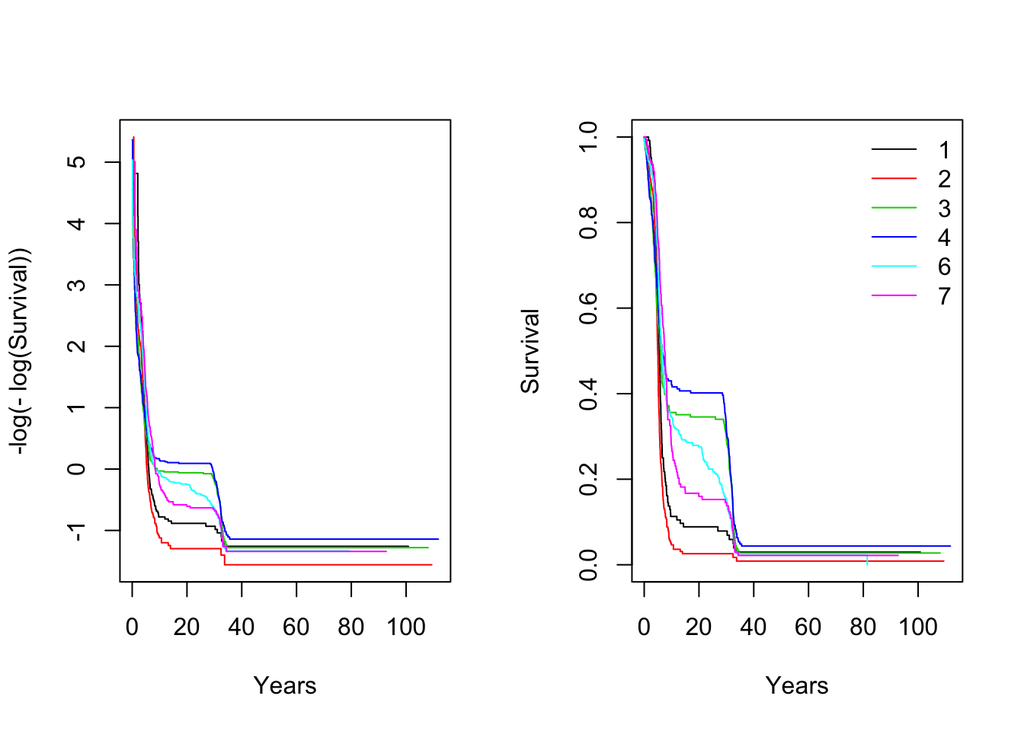

```r
med.fit.center.km=survfit(Surv(time_surg,surgery_status)~center,data=med.rf)
par(mfrow=c(1,2))
plot(med.fit.center.km, fun = function (s) -log(-log(s)), xlab = "Years", ylab = "-log(- log(Survival))", col = 1:7)

plot(med.fit.center.km, xlab = "Years", ylab = "Survival", col = 1:7)
legend("topright", levels(med.rf$center), lty = 1, col = 1:7, bty = "n")
```

The plot in the right panel of the ﬁgure is the classical Kaplan-Meier estimator (survival probabilitieson the y-axis). The plot in the left panel has − log[− log{S(t)}] on the y-axis - transformation of the survival function S(t).

### Part1 - Only adjust for stage

```r
med.fit.stage.cox=coxph(Surv(time_surg,surgery_status)~center*stage_n,data=cancors_select)
summary(med.fit.stage.cox)
```

```
## Call:
## coxph(formula = Surv(time_surg, surgery_status) ~ center * stage_n,
##     data = cancors_select)
##
##   n= 1211, number of events= 1168
##
##                     coef exp(coef) se(coef)      z Pr(>|z|)
## center2          0.19349   1.21348  0.28454  0.680  0.49649
## center3         -0.51722   0.59618  0.29049 -1.780  0.07500 .
## center4         -0.88135   0.41422  0.27747 -3.176  0.00149 **
## center6         -0.56156   0.57032  0.27045 -2.076  0.03786 *
## center7         -0.66513   0.51421  0.30161 -2.205  0.02744 *
## stage_n         -0.09515   0.90924  0.08491 -1.121  0.26248
## center2:stage_n  0.07115   1.07374  0.10513  0.677  0.49858
## center3:stage_n  0.04584   1.04690  0.10927  0.419  0.67486
## center4:stage_n  0.14836   1.15993  0.10567  1.404  0.16031
## center6:stage_n  0.10091   1.10617  0.10063  1.003  0.31596
## center7:stage_n  0.12221   1.12999  0.11368  1.075  0.28235
## ---
## Signif. codes:  0 '***' 0.001 '**' 0.01 '*' 0.05 '.' 0.1 ' ' 1
##
##                 exp(coef) exp(-coef) lower .95 upper .95
## center2            1.2135     0.8241    0.6948    2.1195
## center3            0.5962     1.6774    0.3374    1.0535
## center4            0.4142     2.4142    0.2405    0.7135
## center6            0.5703     1.7534    0.3357    0.9690
## center7            0.5142     1.9447    0.2847    0.9287
## stage_n            0.9092     1.0998    0.7698    1.0739
## center2:stage_n    1.0737     0.9313    0.8738    1.3194
## center3:stage_n    1.0469     0.9552    0.8451    1.2969
## center4:stage_n    1.1599     0.8621    0.9429    1.4269
## center6:stage_n    1.1062     0.9040    0.9082    1.3473
## center7:stage_n    1.1300     0.8850    0.9043    1.4120
##
## Concordance= 0.561  (se = 0.01 )
## Likelihood ratio test= 94.25  on 11 df,   p=2e-15
## Wald test            = 102.9  on 11 df,   p=<2e-16
## Score (logrank) test = 106.9  on 11 df,   p=<2e-16
```

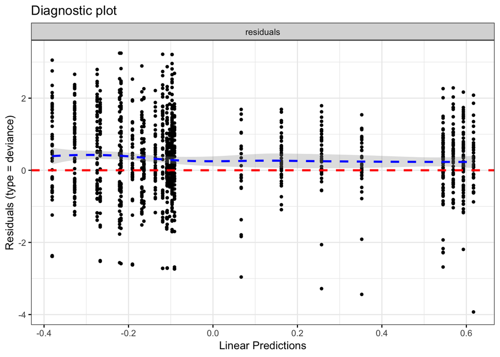

```r
#ggcoxdiagnostics(med.fit.center.stage.cox, type = "schoenfeld", ox.scale = "observation.id",title = "Diagnostic plot")
ggcoxdiagnostics(med.fit.stage.cox, type = "deviance",ox.scale = "linear.predictions",title = "Diagnostic plot")
```